# Sugestão de carteira de investimentos em Fundos do Banco Itaú

*Neste trabalho é sugerido ao usuário, com base em seu orçamento, em quais fundos ele/ela deve investir a fim de maximizar sua rentabilidade anual. Os investimentos são divididos em três tipos:* *Alto Risco, Médio Risco e Baixo Risco*. *Para cada um deles o usuário possui um orçamento diferente.*

*Este problema foi modelado segundo o Problema da Mochila Compartimentada, onde os Objetos a serem selecionados são os Fundos; o Orçamento disponível para cada categoria de investimentos corresponde à Capacidade de cada compartimento; o Valor Mínimo a ser investido corresponde ao Peso; e a Rentabilidade em 12 Meses do fundo corresponde ao Ganho.*

*Como esta análise é do tipo 0 ou 1, ela considera que o usuário só investirá o valor mínimo*

*Para o cálculo da solução foram utilizados Algoritmos Genéticos, a partir do framework Pyeasyga.*

*A base de dados utilizada são os fundos de investimento oferecidos pelo Banco Itaú, disponível em:* https://www.itau.com.br/investimentos/fundos/rentabilidade/

## Preparação do ambiente

*Importação das bibliotecas*

```python
from pyeasyga import pyeasyga
import pandas as pd
import matplotlib.pyplot as plt
import random

%matplotlib inline
```

*Carregamento do dataset*

```python
dataset = pd.read_excel("dataset_itau.xlsx")
dataset.shape
```

```
(208, 8)
```

## Manipulação dos dados

*Exclusão da coluna textual "resgate"*

```python
dataset.drop(columns=['resgate'], inplace=True)
```

*Alteração dos cabeçalhos para manipulação pelo pacote Pandas*

```python
dataset.columns = ['nome_fundo', 'risco', 'valor_minimo', 'rentabilidade_12_meses', 'rentabilidade_anual', 'rentabilidade_mensal', 'taxa_adm']
dataset.head()
```

|  | nome_fundo | risco | valor_minimo | rentabilidade_12_meses | rentabilidade_anual | rentabilidade_mensal | taxa_adm |
| --- | --- | --- | --- | --- | --- | --- | --- |
| 0 | A1 Hedge Seleção Multimercado | alto | 5000 | 0.0135 | -0.033 | -0.0003 | 0.021 |
| 1 | Absolute Vertex Seleção Multimercado | alto | 5000 | 0.0696 | 0.0315 | -0.0019 | 0.025 |
| 2 | Adam Advanced PVT Multimercado Crédito Privado | alto | 50000 | 0.0612 | 0.0086 | -0.0064 | 0.019 |
| 3 | Adam Exclusivo Seleção Multimercado | alto | 50000 | 0.022 | 0.0082 | -0.0001 | 0.020 |
| 4 | Apex Ações Seleção | alto | 1 | 0.2088 | 0.0484 | -0.0104 | 0.025 |

*São excluídos da análise os fundos com menos de 6 meses, pois não é possível calcular sua rentabilidade*

```python
dataset.drop(dataset.loc[dataset['rentabilidade_12_meses']=='fundo com menos de 6 meses'].index, inplace=True)
dataset.shape
```

```
(177, 7)
```

*Criação do campo calculado "rentabilidade real ao ano", obtido pela subtração da "rentabilidade em 12 meses" pela "taxa de administração" cobrada pelo banco. O resultado de alguns fundos foi negativo, indicando que a rentabilidade era inferior à taxa cobrada.*

```python
dataset['rentabilidade_real_aa'] = dataset['rentabilidade_12_meses']-dataset['taxa_adm']
dataset.head()
```

|  | nome_fundo | risco | valor_minimo | rentabilidade_12_meses | rentabilidade_anual | rentabilidade_mensal | taxa_adm | rentabilidade_real_aa |
| --- | --- | --- | --- | --- | --- | --- | --- | --- |
| 0 | A1 Hedge Seleção Multimercado | alto | 5000 | 0.0135 | -0.033 | -0.0003 | 0.021 | -0.0075 |
| 1 | Absolute Vertex Seleção Multimercado | alto | 5000 | 0.0696 | 0.0315 | -0.0019 | 0.025 | 0.0446 |
| 2 | Adam Advanced PVT Multimercado Crédito Privado | alto | 50000 | 0.0612 | 0.0086 | -0.0064 | 0.019 | 0.0422 |
| 3 | Adam Exclusivo Seleção Multimercado | alto | 50000 | 0.022 | 0.0082 | -0.0001 | 0.020 | 0.002 |
| 4 | Apex Ações Seleção | alto | 1 | 0.2088 | 0.0484 | -0.0104 | 0.025 | 0.1838 |

*Exclusão dos fundos não rentáveis, com rentablidade real ao ano negativa*

```python
dataset.drop(dataset.loc[dataset['rentabilidade_real_aa']<0].index, inplace=True)
dataset.shape
```

```
(138, 8)
```

*Exclusão dos fundos cujo valor mínimo de investimento é inferior a 100 reais, pois esta análise considera a rentabilidade sobre o valor mínimo*

```python
dataset.drop(dataset.loc[dataset['valor_minimo']<100].index, inplace=True)
dataset.shape
```

```
(81, 8)
```

## Criação dos parâmetros

*Solicitação ao usuário dos respectivos orçamentos*

```python
budget_alto = int(input('Qual o valor que você tem disponível para investimentos de ALTO RISCO? \n'))
```

```
Qual o valor que você tem disponível para investimentos de ALTO RISCO?
250000
```

```python
budget_medio = int(input('Qual o valor que você tem disponível para investimentos de MÉDIO RISCO? \n'))
```

```
Qual o valor que você tem disponível para investimentos de MÉDIO RISCO?
250000
```

```python
budget_baixo = int(input('Qual o valor que você tem disponível para investimentos de BAIXO RISCO? \n'))
```

```
Qual o valor que você tem disponível para investimentos de BAIXO RISCO?
250000
```

*Criação das listas com os valores dos Pesos Ganhos a partir do dataset*

```python
ganhos_list = list(dataset['rentabilidade_real_aa']*dataset['valor_minimo'])
ganhos_map = map(lambda x: round(x, 3), ganhos_list)
ganhos = list(ganhos_map)
ganhos
```

```
[223.0,
 2110.0,
 100.0,
 1054.0,
 372.0,
 1786.0,
 45.7,
 288.0,
 166.5,
 19355.0,
 792.5,
 26.8,
 280.0,
 250.5,
 384.8,
 388.9,
 389.0,
 565.5,
 203.5,
 654.0,
 412.0,
 846.0,
 47.6,
 1083.5,
 1727.5,
 56.1,
 1610.0,
 1108.0,
 355.74,
 4.45,
 34.9,
 469.2,
 62.0,
 27.69,
 1030.0,
 656.0,
 27.76,
 416.0,
 175.0,
 15.7,
```

[output cut: 26 more lines]

```
 16.0,
 128.0,
 726.0,
 1020.5,
 3429.0,
 931.0,
 1315.0,
 361.08,
 356.01,
 356.13,
 360.93,
 768.0,
 31.4,
 21.8,
 1102.5]
```

```python
pesos_list = list(dataset['valor_minimo'])
pesos_map = map(lambda x: round(x, 3), pesos_list)
pesos = list(pesos_map)
pesos
```

```
[5000,
 50000,
 50000,
 20000,
 10000,
 5000,
 200,
 1000,
 5000,
 350000,
 5000,
 1000,
 50000,
 1000,
 1000,
 1000,
 1000,
 1500,
 5000,
 20000,
 5000,
 20000,
 1000,
 5000,
 5000,
 1000,
 100000,
 5000,
 300,
 500,
 1000,
 1000,
 1000,
 100,
 100000,
 10000,
 100,
 10000,
 10000,
 1000,
```

[output cut: 26 more lines]

```
 5000,
 10000,
 20000,
 5000,
 10000,
 10000,
 5000,
 300,
 300,
 300,
 300,
 10000,
 500,
 1000,
 25000]
```

*Criação do dicionário de dados fornecido como entrada para o Framework*

```python
dados = []
for i in range(dataset.shape[0]):
    dicio = {'nome': dataset.iloc[i]['risco'], 'value': ganhos[i], 'weight': pesos[i]}
    dados.append(dicio)
dados
```

```
[{'nome': 'alto', 'value': 223.0, 'weight': 5000},
 {'nome': 'alto', 'value': 2110.0, 'weight': 50000},
 {'nome': 'alto', 'value': 100.0, 'weight': 50000},
 {'nome': 'alto', 'value': 1054.0, 'weight': 20000},
 {'nome': 'alto', 'value': 372.0, 'weight': 10000},
 {'nome': 'alto', 'value': 1786.0, 'weight': 5000},
 {'nome': 'alto', 'value': 45.7, 'weight': 200},
 {'nome': 'alto', 'value': 288.0, 'weight': 1000},
 {'nome': 'alto', 'value': 166.5, 'weight': 5000},
 {'nome': 'médio', 'value': 19355.0, 'weight': 350000},
 {'nome': 'alto', 'value': 792.5, 'weight': 5000},
 {'nome': 'baixo', 'value': 26.8, 'weight': 1000},
 {'nome': 'baixo', 'value': 280.0, 'weight': 50000},
 {'nome': 'alto', 'value': 250.5, 'weight': 1000},
 {'nome': 'alto', 'value': 384.8, 'weight': 1000},
 {'nome': 'alto', 'value': 388.9, 'weight': 1000},
 {'nome': 'alto', 'value': 389.0, 'weight': 1000},
 {'nome': 'alto', 'value': 565.5, 'weight': 1500},
 {'nome': 'alto', 'value': 203.5, 'weight': 5000},
 {'nome': 'alto', 'value': 654.0, 'weight': 20000},
 {'nome': 'alto', 'value': 412.0, 'weight': 5000},
 {'nome': 'alto', 'value': 846.0, 'weight': 20000},
 {'nome': 'alto', 'value': 47.6, 'weight': 1000},
 {'nome': 'alto', 'value': 1083.5, 'weight': 5000},
 {'nome': 'alto', 'value': 1727.5, 'weight': 5000},
 {'nome': 'médio', 'value': 56.1, 'weight': 1000},
 {'nome': 'baixo', 'value': 1610.0, 'weight': 100000},
 {'nome': 'alto', 'value': 1108.0, 'weight': 5000},
 {'nome': 'alto', 'value': 355.74, 'weight': 300},
 {'nome': 'médio', 'value': 4.45, 'weight': 500},
 {'nome': 'médio', 'value': 34.9, 'weight': 1000},
 {'nome': 'alto', 'value': 469.2, 'weight': 1000},
 {'nome': 'médio', 'value': 62.0, 'weight': 1000},
 {'nome': 'alto', 'value': 27.69, 'weight': 100},
 {'nome': 'baixo', 'value': 1030.0, 'weight': 100000},
 {'nome': 'médio', 'value': 656.0, 'weight': 10000},
 {'nome': 'alto', 'value': 27.76, 'weight': 100},
 {'nome': 'alto', 'value': 416.0, 'weight': 10000},
 {'nome': 'alto', 'value': 175.0, 'weight': 10000},
 {'nome': 'baixo', 'value': 15.7, 'weight': 1000},
```

[output cut: 26 more lines]

```
 {'nome': 'alto', 'value': 16.0, 'weight': 5000},
 {'nome': 'alto', 'value': 128.0, 'weight': 10000},
 {'nome': 'médio', 'value': 726.0, 'weight': 20000},
 {'nome': 'alto', 'value': 1020.5, 'weight': 5000},
 {'nome': 'alto', 'value': 3429.0, 'weight': 10000},
 {'nome': 'alto', 'value': 931.0, 'weight': 10000},
 {'nome': 'alto', 'value': 1315.0, 'weight': 5000},
 {'nome': 'alto', 'value': 361.08, 'weight': 300},
 {'nome': 'alto', 'value': 356.01, 'weight': 300},
 {'nome': 'alto', 'value': 356.13, 'weight': 300},
 {'nome': 'alto', 'value': 360.93, 'weight': 300},
 {'nome': 'alto', 'value': 768.0, 'weight': 10000},
 {'nome': 'alto', 'value': 31.4, 'weight': 500},
 {'nome': 'alto', 'value': 21.8, 'weight': 1000},
 {'nome': 'alto', 'value': 1102.5, 'weight': 25000}]
```

*Definição dos parâmetros do Algoritmo Genético*

```python
ga = pyeasyga.GeneticAlgorithm(dados,
                               population_size=20,
                               generations=500,
                               crossover_probability=0.8,
                               mutation_probability=0.1,
                               elitism=True,
                               maximise_fitness=True)
```

*Criação da função de avaliação (Fitness), que penaliza as soluções que excedem o orçamento*

```python
saveValues = []

def fitness(individual, data):
    weights_alto, weights_medio, weights_baixo = 0, 0, 0
    values = 0
    for selected, item in zip(individual, data):
        if selected:
            values += item.get('value')
            if item.get('nome') == 'alto':
                weights_alto += item.get('weight')
            elif item.get('nome') == 'medio':
                weights_medio += item.get('weight')
            else:
                weights_baixo += item.get('weight')
    if weights_alto > budget_alto or weights_medio > budget_medio or weights_baixo > budget_baixo:
        values = 0
    saveValues.append(values)
    return values

ga.fitness_function = fitness
```

## Resultados do modelo

*Execução do modelo*

```python
ga.run()
```

*Valor obtido e fundos selecionados pelo melhor indivíduo*

```python
ga.best_individual()
```

```
(36230.29000000001,
 [0,
  0,
  0,
  1,
  1,
  1,
  1,
  0,
  0,
  0,
  1,
  1,
  1,
  1,
  1,
  1,
  1,
  1,
  1,
  1,
  0,
  1,
  1,
  1,
  1,
  1,
  0,
  1,
  1,
  1,
  0,
  1,
  1,
  1,
  0,
  1,
  1,
  1,
  0,
```

[output cut: 27 more lines]

```
  1,
  0,
  1,
  1,
  1,
  1,
  1,
  1,
  1,
  1,
  1,
  1,
  1,
  0,
  1])
```

*Gráfico: Rentabilidade obtida vs. Iterações*

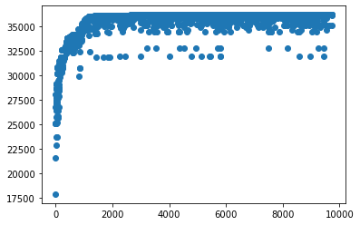

```python
saveValues = [value for value in saveValues if value != 0]
plt.plot(saveValues, 'o')
plt.show()
```

*Atribuindo os fundos selecionados ao dataset*

```python
dataset['resultado'] = ga.best_individual()[1]
dataset.head(81)
```

|  | nome_fundo | risco | valor_minimo | rentabilidade_12_meses | rentabilidade_anual | rentabilidade_mensal | taxa_adm | rentabilidade_real_aa | resultado |
| --- | --- | --- | --- | --- | --- | --- | --- | --- | --- |
| 1 | Absolute Vertex Seleção Multimercado | alto | 5000 | 0.0696 | 0.0315 | -0.0019 | 0.0250 | 0.0446 | 0 |
| 2 | Adam Advanced PVT Multimercado Crédito Privado | alto | 50000 | 0.0612 | 0.0086 | -0.0064 | 0.0190 | 0.0422 | 0 |
| 3 | Adam Exclusivo Seleção Multimercado | alto | 50000 | 0.022 | 0.0082 | -0.0001 | 0.0200 | 0.002 | 0 |
| 8 | Bahia AM Maraú Seleção Multimercado | alto | 20000 | 0.0747 | 0.0004 | -0.0086 | 0.0220 | 0.0527 | 1 |
| 9 | Bahia AM Seleção Multimercado | alto | 10000 | 0.0542 | 0.0097 | -0.0032 | 0.0170 | 0.0372 | 1 |
| ... | ... | ... | ... | ... | ... | ... | ... | ... | ... |
| 199 | Unibanco FMP FGTS Vale | alto | 300 | 1.2131 | 0.3844 | 0.0099 | 0.0100 | 1.2031 | 1 |
| 202 | Verde AM Long Bias Seleção Ações | alto | 10000 | 0.1018 | 0.0598 | 0.002 | 0.0250 | 0.0768 | 1 |
| 203 | Vinci Mosaico Seleção Ações | alto | 500 | 0.0825 | 0.0487 | -0.0008 | 0.0197 | 0.0628 | 1 |
| 205 | Vinland Macro Seleção Multimercado | alto | 1000 | 0.0408 | 0.0215 | -0.0073 | 0.0190 | 0.0218 | 0 |
| 207 | Western Asset Macro OPPS Seleção Multimercado | alto | 25000 | 0.0666 | -0.0152 | 0.0004 | 0.0225 | 0.0441 | 1 |

81 rows × 9 columns

### Resultados: Fundos de Alto Risco

```python
investimentos_risco_alto = dataset.loc[(dataset['risco'] == 'alto') & (dataset['resultado'] == 1)].sum()
```

*Total investido*

```python
investimentos_risco_alto['valor_minimo']
```

```
249900
```

*Quantidade de fundos selecionados*

```python
investimentos_risco_alto['resultado']
```

```
47
```

### Resultados: Fundos de Médio Risco

```python
investimentos_risco_medio = dataset.loc[(dataset['risco'] == 'medio') & (dataset['resultado'] == 1)].sum()
```

*Total investido*

```python
investimentos_risco_medio['valor_minimo']
```

```
0.0
```

*Quantidade de fundos selecionados*

```python
investimentos_risco_medio['resultado']
```

```
0.0
```

### Resultados: Fundos de Baixo Risco

```python
investimentos_risco_baixo = dataset.loc[(dataset['risco'] == 'baixo') & (dataset['resultado'] == 1)].sum()
```

*Total investido*

```python
investimentos_risco_baixo['valor_minimo']
```

```
157000
```

*Quantidade de fundos selecionados*

```python
investimentos_risco_baixo['resultado']
```

```
5
```